# Manipulando dados e customizando gráficos

Marcus Carvalho (adaptado de Alison Hill)

> Este documento foi traduzido e adaptado do curso [Principles & Practice of Data Visualization](https://github.com/apreshill/data-vis-labs-2018). A licença CC BY-NC 4.0 pode ser lida [aqui](https://github.com/apreshill/data-vis-labs-2018/blob/master/LICENSE.md). Copyright © Alison Presmanes Hill.

# 1 Objetivos do lab

- Colocar a mão na massa!
- Conhecer mais coisas que você pode fazer
- Desenvolver suas preferências pessoais para visualização de dados

# 2 Carregando pacotes

Para este lab, nós vamos precisar de alguns pacotes do R. Se você não já tiver instalado, rode os comandos abaixo no Console para instalar:

```r
pacotes <- c("tidyverse", "here", "ggthemes", "lubridate")
install.packages(pacotes, dependencies = TRUE)
```

Em seguida, carregue os pacotes necessários:

```r
library(ggthemes)
library(here)
library(lubridate)
library(tidyverse)
```

# 3 Lendo e manipulando dados

Em seguida, carregue os dados de casos da COVID-19 para o Brasil a partir de uma URL:

```r
url_br <- "https://raw.githubusercontent.com/marcuswac/covid-br-data/master/covid-br-ms-country.csv"
covid_br <- read_csv(url_br, col_types = cols(data = col_date()))
```

Você também pode salvar os dados em um arquivo CSV local. Eu salvei em um diretório chamado `data` e construi o caminho para o CSV usando o comando `here` do pacote `here`:

```r
covid_br <- read_csv(here::here("data", "covid-br-ms-country.csv"),
                     col_types = cols(data = col_date()))
```

Nós usamos o parâmetro `col_types` para indicar que a coluna `data` é do tipo `date`.

De um jeito ou de outro, carregue os dados e veja se ele está mais ou menos assim:

```r
glimpse(covid_br)
```

```
Rows: 114
Columns: 16
$ regiao                <chr> "Brasil", "Brasil", "Brasil", "Brasil", "Brasil…
$ estado                <lgl> NA, NA, NA, NA, NA, NA, NA, NA, NA, NA, NA, NA,…
$ municipio             <lgl> NA, NA, NA, NA, NA, NA, NA, NA, NA, NA, NA, NA,…
$ coduf                 <dbl> 76, 76, 76, 76, 76, 76, 76, 76, 76, 76, 76, 76,…
$ codmun                <lgl> NA, NA, NA, NA, NA, NA, NA, NA, NA, NA, NA, NA,…
$ codRegiaoSaude        <lgl> NA, NA, NA, NA, NA, NA, NA, NA, NA, NA, NA, NA,…
$ nomeRegiaoSaude       <lgl> NA, NA, NA, NA, NA, NA, NA, NA, NA, NA, NA, NA,…
$ data                  <date> 2020-02-25, 2020-02-26, 2020-02-27, 2020-02-28…
$ semanaEpi             <dbl> 9, 9, 9, 9, 9, 10, 10, 10, 10, 10, 10, 10, 11, …
$ populacaoTCU2019      <dbl> 210147125, 210147125, 210147125, 210147125, 210…
$ casosAcumulado        <dbl> 0, 1, 1, 1, 2, 2, 2, 2, 3, 7, 13, 19, 25, 25, 3…
$ casosNovos            <dbl> 0, 1, 0, 0, 1, 0, 0, 0, 1, 4, 6, 6, 6, 0, 9, 18…
$ obitosAcumulado       <dbl> 0, 0, 0, 0, 0, 0, 0, 0, 0, 0, 0, 0, 0, 0, 0, 0,…
$ obitosNovos           <dbl> 0, 0, 0, 0, 0, 0, 0, 0, 0, 0, 0, 0, 0, 0, 0, 0,…
$ Recuperadosnovos      <dbl> NA, NA, NA, NA, NA, NA, NA, NA, NA, NA, NA, NA,…
$ emAcompanhamentoNovos <dbl> NA, NA, NA, NA, NA, NA, NA, NA, NA, NA, NA, NA,…
```

```r
covid_br
```

| regiao | estado | municipio | coduf | codmun | codRegiaoSaude | nomeRegiaoSaude | data | semanaEpi | populacaoTCU2019 | casosAcumulado | casosNovos | obitosAcumulado | obitosNovos | Recuperadosnovos | emAcompanhamentoNovos |
| --- | --- | --- | --- | --- | --- | --- | --- | --- | --- | --- | --- | --- | --- | --- | --- |
| Brasil | NA | NA | 76 | NA | NA | NA | 2020-02-25 | 9 | 210147125 | 0 | 0 | 0 | 0 | NA | NA |
| Brasil | NA | NA | 76 | NA | NA | NA | 2020-02-26 | 9 | 210147125 | 1 | 1 | 0 | 0 | NA | NA |
| Brasil | NA | NA | 76 | NA | NA | NA | 2020-02-27 | 9 | 210147125 | 1 | 0 | 0 | 0 | NA | NA |
| Brasil | NA | NA | 76 | NA | NA | NA | 2020-02-28 | 9 | 210147125 | 1 | 0 | 0 | 0 | NA | NA |
| Brasil | NA | NA | 76 | NA | NA | NA | 2020-02-29 | 9 | 210147125 | 2 | 1 | 0 | 0 | NA | NA |
| Brasil | NA | NA | 76 | NA | NA | NA | 2020-03-01 | 10 | 210147125 | 2 | 0 | 0 | 0 | NA | NA |
| Brasil | NA | NA | 76 | NA | NA | NA | 2020-03-02 | 10 | 210147125 | 2 | 0 | 0 | 0 | NA | NA |
| Brasil | NA | NA | 76 | NA | NA | NA | 2020-03-03 | 10 | 210147125 | 2 | 0 | 0 | 0 | NA | NA |
| Brasil | NA | NA | 76 | NA | NA | NA | 2020-03-04 | 10 | 210147125 | 3 | 1 | 0 | 0 | NA | NA |
| Brasil | NA | NA | 76 | NA | NA | NA | 2020-03-05 | 10 | 210147125 | 7 | 4 | 0 | 0 | NA | NA |

[output cut: 104 more lines]

```r
covid_br <- covid_br %>%
  mutate(dia_da_semana = lubridate::wday(data, label = TRUE)) %>%
  filter(casosAcumulado >= 10000)

glimpse(covid_br)
```

```
Rows: 75
Columns: 17
$ regiao                <chr> "Brasil", "Brasil", "Brasil", "Brasil", "Brasil…
$ estado                <lgl> NA, NA, NA, NA, NA, NA, NA, NA, NA, NA, NA, NA,…
$ municipio             <lgl> NA, NA, NA, NA, NA, NA, NA, NA, NA, NA, NA, NA,…
$ coduf                 <dbl> 76, 76, 76, 76, 76, 76, 76, 76, 76, 76, 76, 76,…
$ codmun                <lgl> NA, NA, NA, NA, NA, NA, NA, NA, NA, NA, NA, NA,…
$ codRegiaoSaude        <lgl> NA, NA, NA, NA, NA, NA, NA, NA, NA, NA, NA, NA,…
$ nomeRegiaoSaude       <lgl> NA, NA, NA, NA, NA, NA, NA, NA, NA, NA, NA, NA,…
$ data                  <date> 2020-04-04, 2020-04-05, 2020-04-06, 2020-04-07…
$ semanaEpi             <dbl> 14, 15, 15, 15, 15, 15, 15, 15, 16, 16, 16, 16,…
$ populacaoTCU2019      <dbl> 210147125, 210147125, 210147125, 210147125, 210…
$ casosAcumulado        <dbl> 10278, 11130, 12056, 13717, 15927, 17857, 19638…
$ casosNovos            <dbl> 1222, 852, 926, 1661, 2210, 1930, 1781, 1089, 1…
$ obitosAcumulado       <dbl> 432, 486, 553, 667, 800, 941, 1056, 1124, 1223,…
$ obitosNovos           <dbl> 73, 54, 67, 114, 133, 141, 115, 68, 99, 105, 20…
$ Recuperadosnovos      <dbl> NA, NA, NA, NA, NA, NA, NA, NA, NA, NA, NA, NA,…
$ emAcompanhamentoNovos <dbl> NA, NA, NA, NA, NA, NA, NA, NA, NA, NA, NA, NA,…
$ dia_da_semana         <ord> Sáb, Dom, Seg, Ter, Qua, Qui, Sex, Sáb, Dom, Se…
```

# 4 Plotando os dados

Vamos iniciar com um gráfico simples:

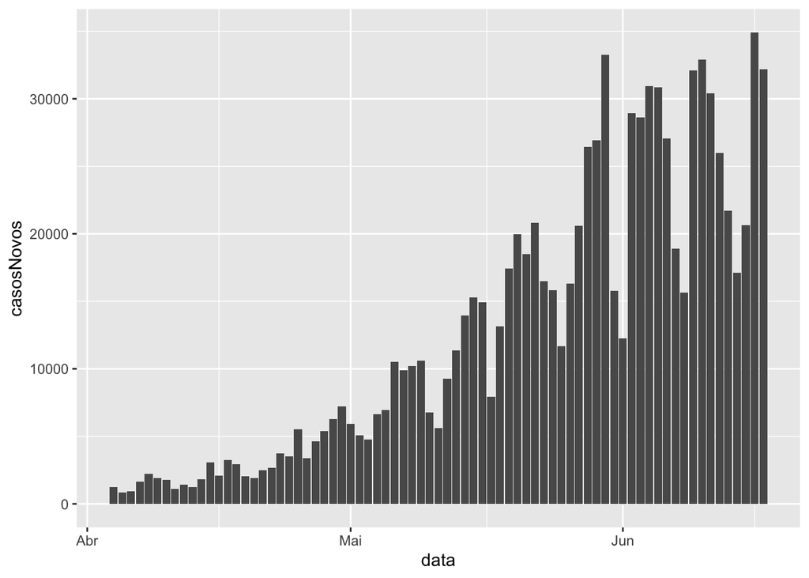

```r
ggplot(covid_br, aes(x = data, y = casosNovos)) +
  geom_col()
```

# 5 Adicione texto nos eixos e título

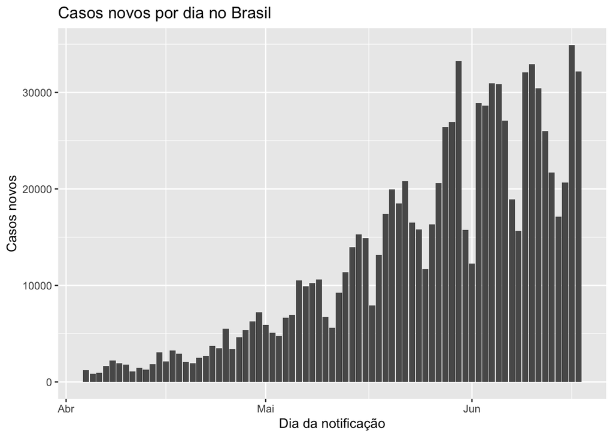

```r
ggplot(covid_br, aes(x = data, y = casosNovos)) +
  geom_col() +
  labs(x = "Dia da notificação", y = "Casos novos") +
  ggtitle("Casos novos por dia no Brasil")
```

# 6 Brinque com cores

**Desafio #1:**

Faça 3 versões do último plot que fizemos:

- **No primeiro,** faça as barras com linhas ao redor (`colour`) brancas.
- **No segundo,** faça as barras com linhas ao redor (`colour`) brancas e preenchidas (`fill`) de azul marinho (“navyblue”).
- **No terceiro,** faça as barras com linhas ao redor brancas (`colour`) e preencha com cores diferentes (`fill`) para cada dia da semana (por enquanto use as cores padrão).

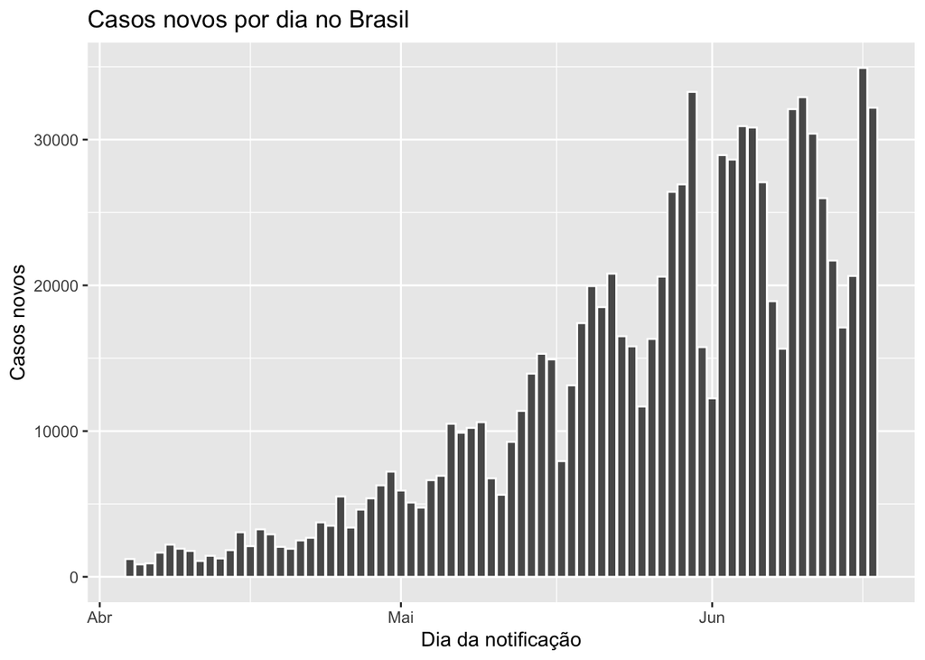

```r
ggplot(covid_br, aes(x = data, y = casosNovos)) +
  geom_col(colour = "white") +
  labs(x = "Dia da notificação", y = "Casos novos") +
  ggtitle("Casos novos por dia no Brasil")
```

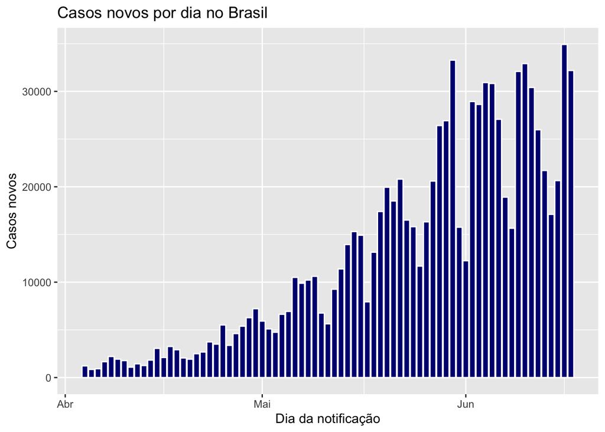

```r
ggplot(covid_br, aes(x = data, y = casosNovos)) +
  geom_col(colour = "white", fill = "navyblue") +
  labs(x = "Dia da notificação", y = "Casos novos") +
  ggtitle("Casos novos por dia no Brasil")
```

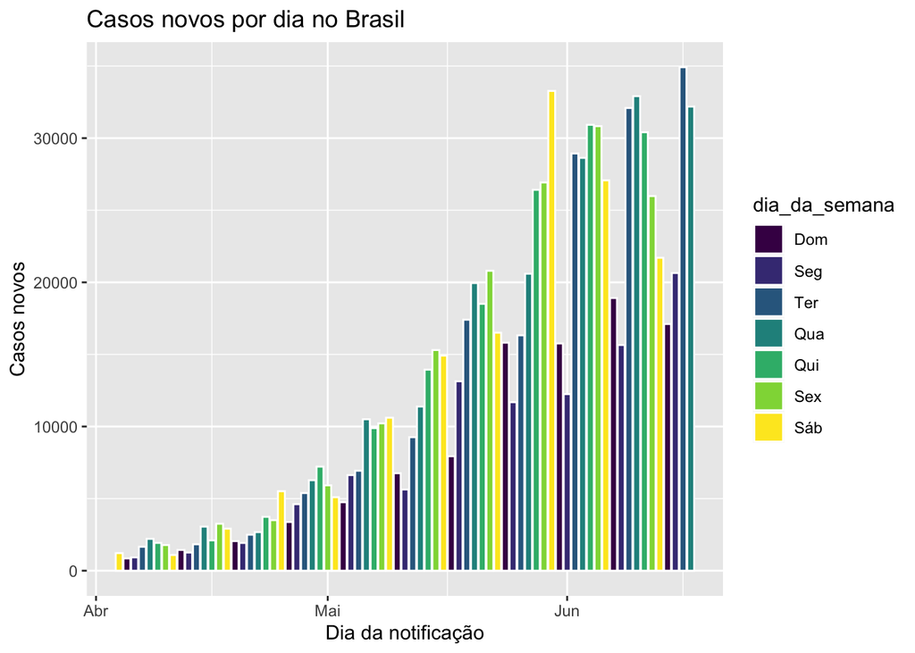

```r
ggplot(covid_br, aes(x = data, y = casosNovos)) +
  geom_col(aes(fill = dia_da_semana), colour = "white") +
  labs(x = "Dia da notificação", y = "Casos novos") +
  ggtitle("Casos novos por dia no Brasil")
```

**Desafio #2:**

E se você quiser mudar a legenda do último plot que você fez? Procure no Google como fazer o seguinte:

- Remover o título da legenda
- Colocar a legenda em um espaço vazio dentro do gráfico

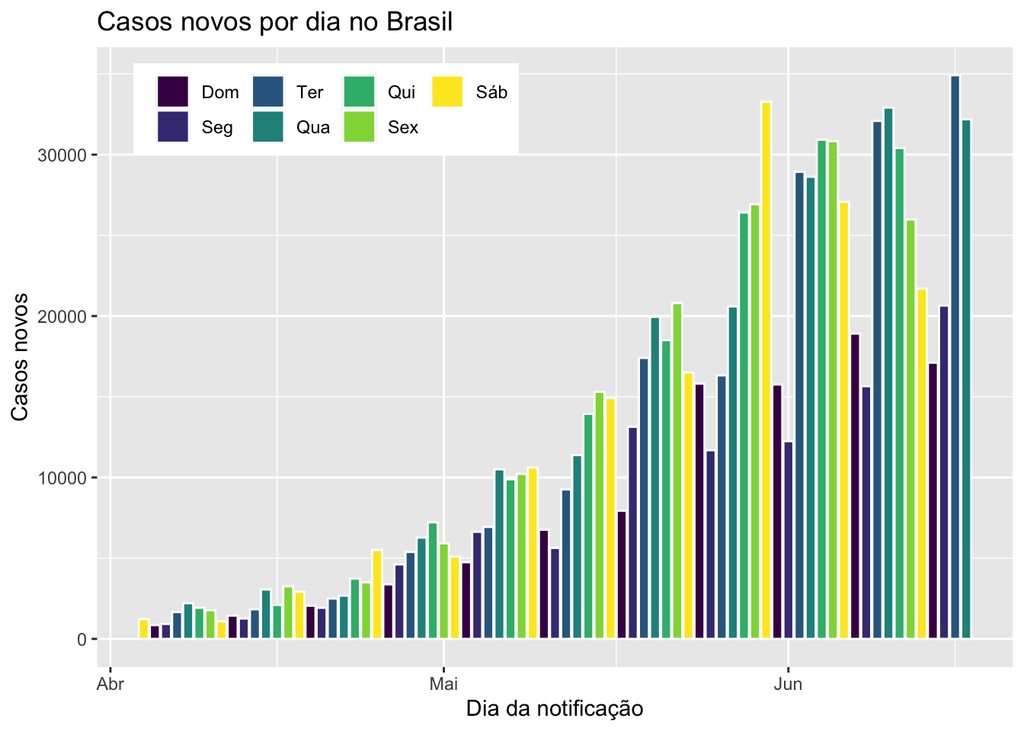

```r
ggplot(covid_br, aes(x = data, y = casosNovos)) +
  geom_col(aes(fill = dia_da_semana), colour = "white") +
  labs(x = "Dia da notificação", y = "Casos novos") +
  ggtitle("Casos novos por dia no Brasil") +
  theme(legend.title = element_blank(), legend.position = c(0.25, 0.9),
        legend.direction = "horizontal")
```

**Desafio #3:**

Você consegue ver algum padrão na quantidade de casos notificados de acordo com o dia da semana?

- Quais dias da semana geralmente se tem uma diminuição mais acentuada nas notificações de casos?
- Quais dias da semana geralmente se tem um aumento mais acentuado (pico) nas notificações de casos?
- Você tem alguma possível explicação para esta variação?

# 7 Modificando a base de dados

Agora vamos modificar um pouco a base de dados. Vamos carregar os dados de casos por estado e agregar os dados por região.

```r
url_estados <- "https://raw.githubusercontent.com/marcuswac/covid-br-data/master/covid-br-ms-states.csv"
covid_estados <- read_csv(url_estados, col_types = cols(data = col_date()))

glimpse(covid_estados)
```

```
Rows: 3,186
Columns: 16
$ regiao                <chr> "Norte", "Norte", "Norte", "Norte", "Norte", "N…
$ estado                <chr> "RO", "RO", "RO", "RO", "RO", "RO", "RO", "RO",…
$ municipio             <lgl> NA, NA, NA, NA, NA, NA, NA, NA, NA, NA, NA, NA,…
$ coduf                 <dbl> 11, 11, 11, 11, 11, 11, 11, 11, 11, 11, 11, 11,…
$ codmun                <lgl> NA, NA, NA, NA, NA, NA, NA, NA, NA, NA, NA, NA,…
$ codRegiaoSaude        <lgl> NA, NA, NA, NA, NA, NA, NA, NA, NA, NA, NA, NA,…
$ nomeRegiaoSaude       <lgl> NA, NA, NA, NA, NA, NA, NA, NA, NA, NA, NA, NA,…
$ data                  <date> 2020-02-25, 2020-02-26, 2020-02-27, 2020-02-28…
$ semanaEpi             <dbl> 9, 9, 9, 9, 9, 10, 10, 10, 10, 10, 10, 10, 11, …
$ populacaoTCU2019      <dbl> 1777225, 1777225, 1777225, 1777225, 1777225, 17…
$ casosAcumulado        <dbl> 0, 0, 0, 0, 0, 0, 0, 0, 0, 0, 0, 0, 0, 0, 0, 0,…
$ casosNovos            <dbl> 0, 0, 0, 0, 0, 0, 0, 0, 0, 0, 0, 0, 0, 0, 0, 0,…
$ obitosAcumulado       <dbl> 0, 0, 0, 0, 0, 0, 0, 0, 0, 0, 0, 0, 0, 0, 0, 0,…
$ obitosNovos           <dbl> 0, 0, 0, 0, 0, 0, 0, 0, 0, 0, 0, 0, 0, 0, 0, 0,…
$ Recuperadosnovos      <lgl> NA, NA, NA, NA, NA, NA, NA, NA, NA, NA, NA, NA,…
$ emAcompanhamentoNovos <lgl> NA, NA, NA, NA, NA, NA, NA, NA, NA, NA, NA, NA,…
```

Nós queremos agora contar a quantidade de casos diários por região do Brasil. Para isto, iremos precisar das funções `group_by()` para agrupar os estados por data e região, e a função `summarise()` para sumarizar os dados para cada grupo e somar os casos por região (quem já estudou banco de dados vai achar familiar).

**Desafio #4:**

Vamos trabalhar com esse novo conjunto de dados.

- Leia o arquivo “covid-br-ms-states.csv”
- Use a função `group_by()` para agrupar os estados por data e região, e a função `summarise()` para calcular os casos e óbitos região e data. Quem já estudou banco de dados vai achar familiar esses comandos.
- Filtre os dados apenas para o dia 01 de abril em diante

```r
covid_regiao <- covid_estados %>%
  group_by(regiao, data) %>%
  summarise(casosNovos = sum(casosNovos),
            casosAcumulado = sum(casosAcumulado),
            obitosNovos = sum(obitosNovos),
            obitosAcumulado = sum(obitosAcumulado),
            populacao = sum(populacaoTCU2019)) %>%
  filter(data >= lubridate::dmy("01-04-2020")) # dmy:day-month-year

glimpse(covid_regiao)
```

```
Rows: 410
Columns: 7
Groups: regiao [5]
$ regiao          <chr> "Centro-Oeste", "Centro-Oeste", "Centro-Oeste", "Cent…
$ data            <date> 2020-04-01, 2020-04-02, 2020-04-03, 2020-04-04, 2020…
$ casosNovos      <dbl> 34, 28, 62, 81, 33, 26, 49, 59, 61, 52, 54, 58, 51, 7…
$ casosAcumulado  <dbl> 504, 532, 594, 675, 708, 734, 783, 842, 903, 955, 100…
$ obitosNovos     <dbl> 0, 1, 3, 2, 1, 5, 3, 2, 2, 2, 3, 4, 5, 2, 0, 6, 0, 6,…
$ obitosAcumulado <dbl> 5, 6, 9, 11, 12, 17, 20, 22, 24, 26, 29, 33, 38, 40, …
$ populacao       <dbl> 16297074, 16297074, 16297074, 16297074, 16297074, 162…
```

**Desafio #5:**

Vamos fazer uma Análise Exploratória de Dados básica (ou **EDA**, do inglês *Exploratory Data Analysis*) no nosso novo dataset. Use comandos do R para responder o seguinte:

- Qual a região que tem mais casos acumulados no último dia? Qual tem menos?
- Qual a região que tem mais casos acumulados por 100 mil habitantes no último dia? Qual tem menos?

```r
ultimo_dia <- max(covid_regiao$data)

covid_regiao_ultimo_dia <- covid_regiao %>%
  ungroup() %>%
  filter(data == ultimo_dia)

covid_regiao_ultimo_dia %>%
  filter(casosAcumulado == max(casosAcumulado) |
         casosAcumulado == min(casosAcumulado)) %>%
  select(data, regiao, casosAcumulado, populacao)
```

| data | regiao | casosAcumulado | populacao |
| --- | --- | --- | --- |
| 2020-06-21 | Nordeste | 379297 | 57071654 |
| 2020-06-21 | Sul | 51431 | 29975984 |

```r
covid_regiao_ultimo_dia %>%
  ungroup() %>%
  mutate(casosAcumuladoPor100k = (casosAcumulado*100000)/(populacao)) %>%
  filter(casosAcumuladoPor100k == max(casosAcumuladoPor100k) |
         casosAcumuladoPor100k == min(casosAcumuladoPor100k)) %>%
  select(data, regiao, casosAcumuladoPor100k)
```

| data | regiao | casosAcumuladoPor100k |
| --- | --- | --- |
| 2020-06-21 | Norte | 1155.337 |
| 2020-06-21 | Sul | 171.574 |

Vamos plotar agora os casos acumulados no Brasil, destacando a quantidade de casos para cada região.

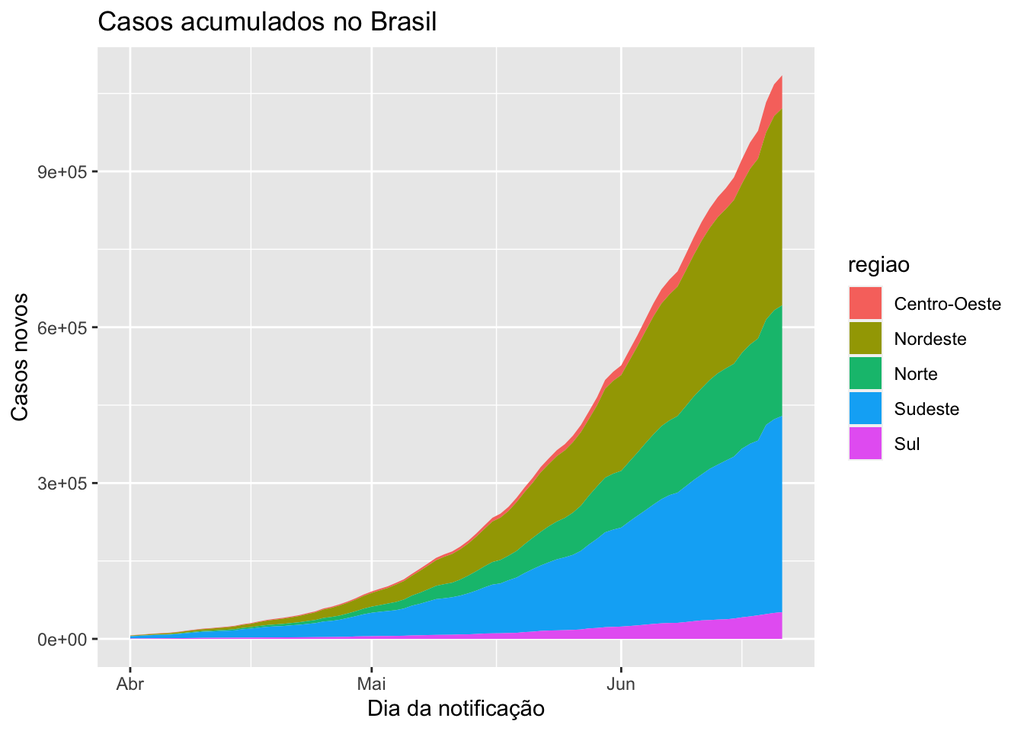

```r
ggplot(covid_regiao, aes(data, casosAcumulado)) +
  geom_area(aes(fill = regiao)) +
  labs(x = "Dia da notificação", y = "Casos novos") +
  ggtitle("Casos acumulados no Brasil")
```

**Desafio #6:**

Faça as seguinte operações no último plot:

- Mude as cores para a paleta de [cores brewer](https://colorbrewer2.org/) `Set1`
- Mude o título da legenda para “Região”
- Salve o plot em uma variável chamada “plot_regiao”

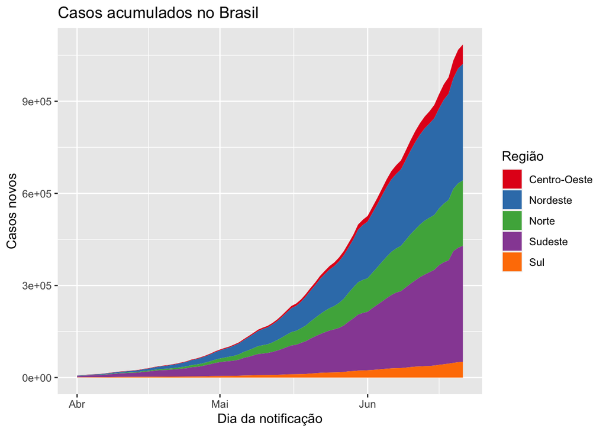

```r
plot_regiao <- ggplot(covid_regiao, aes(data, casosAcumulado)) +
  geom_area(aes(fill = regiao)) +
  scale_fill_brewer(name = "Região", palette = "Set1") +
  labs(x = "Dia da notificação", y = "Casos novos") +
  ggtitle("Casos acumulados no Brasil")

plot_regiao
```

# 8 Brinque com as escalas e coordenadas

Há um espaço em branco nas laterais do plot. A [documentação](http://ggplot2.tidyverse.org/reference/scale_continuous.html) diz que o valor padrão desse espaço é de `c(0.05, 0)` para uma escala contínua. O primeiro parâmetro é um número multiplicativo e o segundo aditivo.

Então, se o eixo x tem 100 dias, por exemplo, haverá um espaço extra em branco de 100*0.05 = 5 dias no início e no fim do eixo x.

Nós podemos modificar esse espaço em branco para colar o gráfico nas margens do eixo x, com o parâmetro `expand` na `scale_x_date` (já que o eixo x é do tipo date):

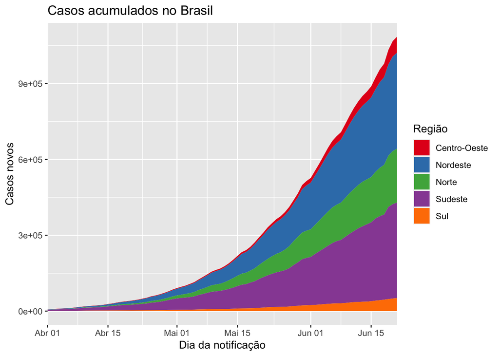

```r
plot_regiao <- plot_regiao +
  scale_x_date(expand = c(0, 0))

plot_regiao
```

Se você quiser dar um zoom para olhar um período mais específico, por exemplo, você pode atualizar as coordenadas.

**Desafio #7:**

Usar `coord_cartesian` para:

- Mudar a faixa do eixo-x apenas de maio até a última data

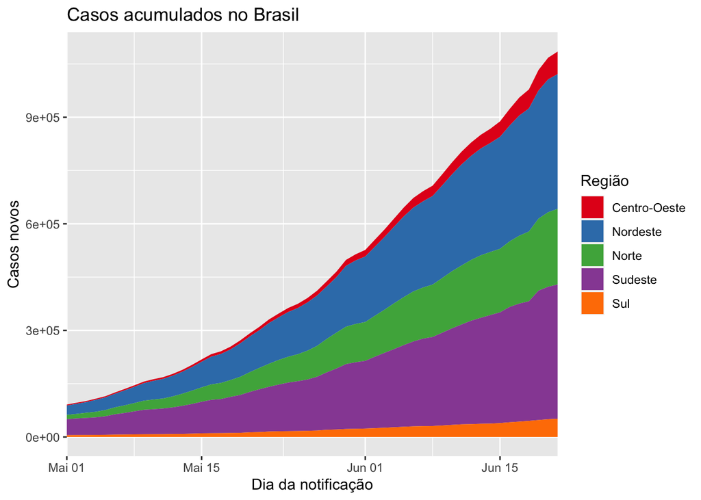

```r
plot_regiao <- plot_regiao +
  coord_cartesian(xlim = c(lubridate::dmy("01-05-2020"), ultimo_dia))

plot_regiao
```

# 9 Brinque com os temas

Vamos mudar algumas configurações do tema:

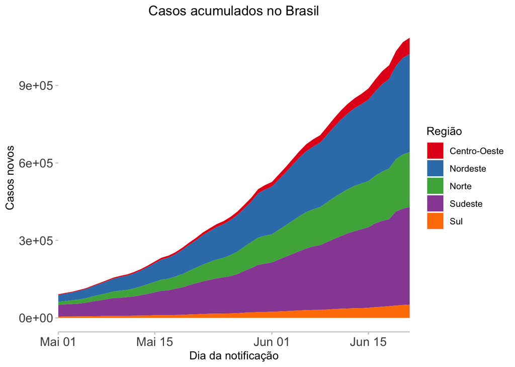

```r
plot_regiao +
  theme(plot.title = element_text(hjust = 0.5)) +
  theme(axis.text = element_text(size = 12)) +
  theme(panel.background = element_blank()) +
  theme(axis.line.x = element_line(color = "gray80", size = 0.5)) +
  theme(axis.ticks = element_line(color = "gray80", size = 0.5))
```

**Lição:**

Você pode mudar *quase tudo* que seu coração desejar mudar!

Nós também podemos salvar tudo isso em um tema customizado.

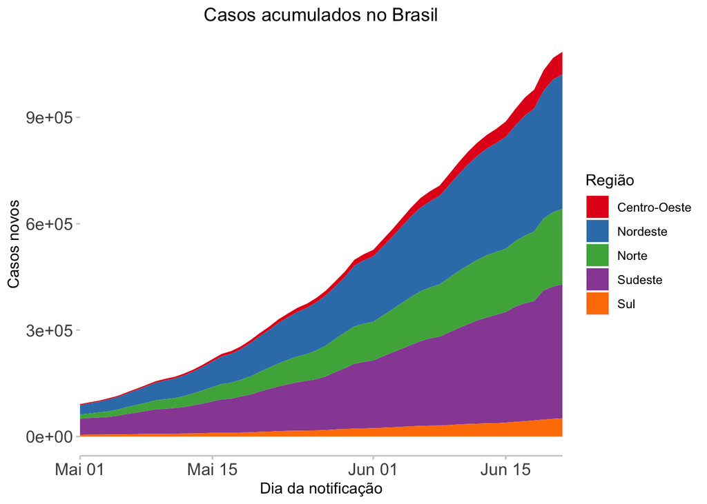

```r
my_theme <- theme(plot.title = element_text(hjust = 0.5),
                  axis.text = element_text(size = 12),
                  panel.background = element_blank(),
                  axis.line.x = element_line(color = "gray80", size = 0.5),
                  axis.ticks = element_line(color = "gray80", size = 0.5))

plot_regiao + my_theme
```

Também podemos usar temas de outras pessoas:

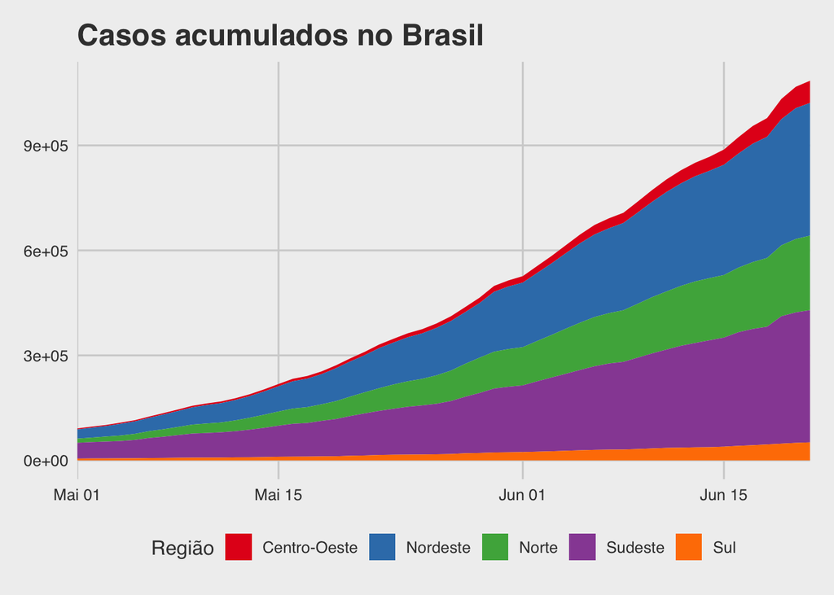

```r
plot_regiao + ggthemes::theme_fivethirtyeight()
```

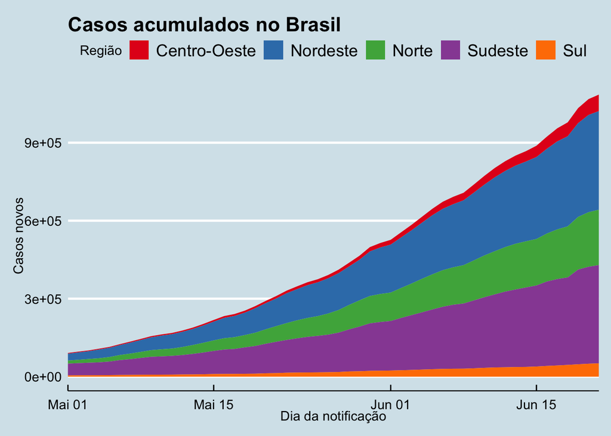

```r
plot_regiao + ggthemes::theme_economist()
```

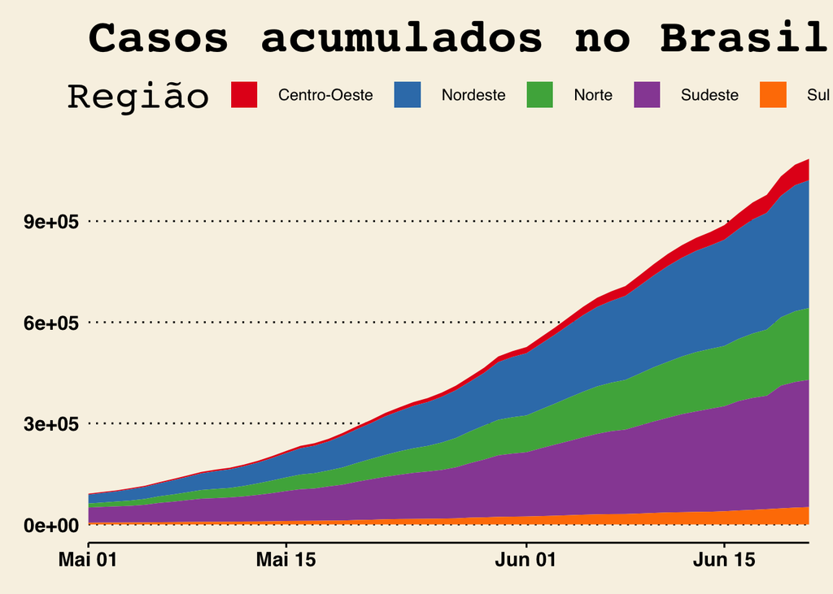

```r
plot_regiao + ggthemes::theme_wsj()
```

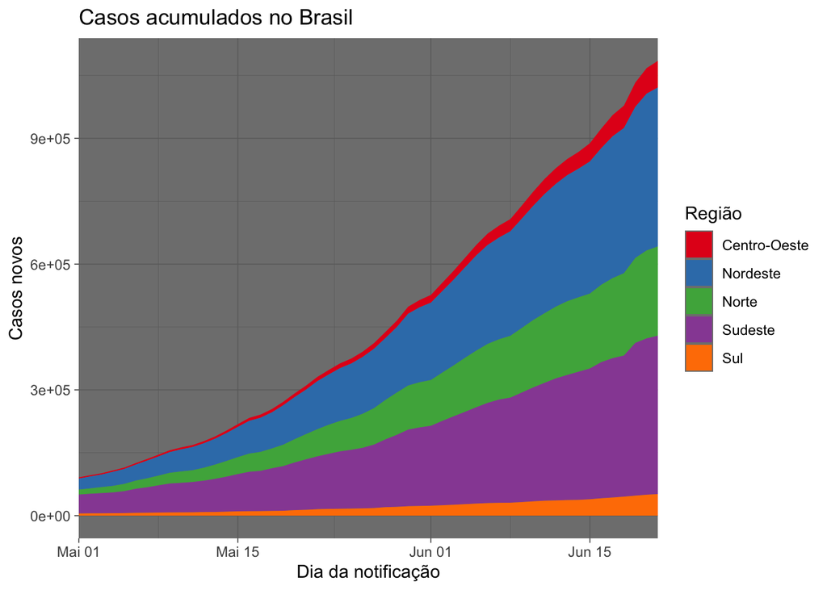

```r
plot_regiao + theme_dark()
```

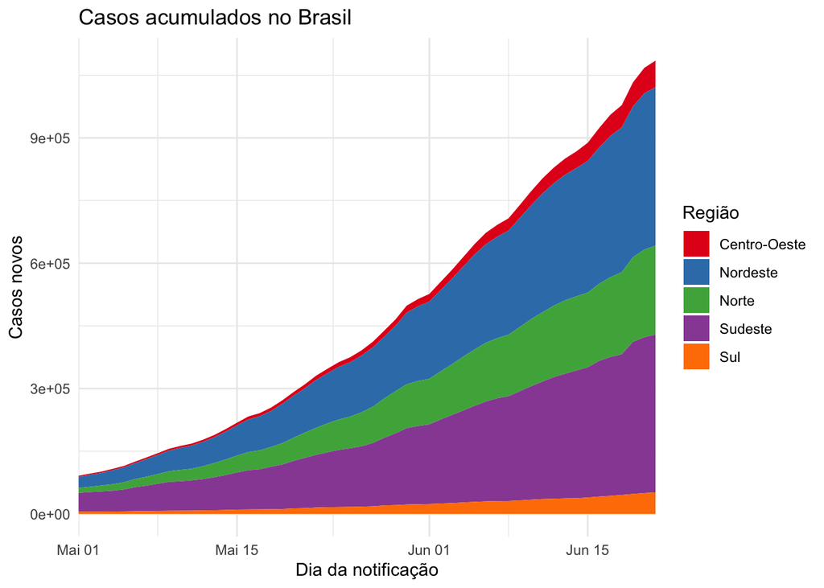

```r
plot_regiao + theme_minimal()
```

# 10 Agora é a sua vez

**Atividade:**

- Crie seu próprio plot com tema customizado, mostrando os casos e/ou óbitos ao longo do tempo para uma ou mais localidades (pode ser país, região, estado ou município).
- Salve o(s) plot(s) em arquivos PNG e envie na atividade do Classroom

Se estiver com dificuldade de gerar gráficos com outros dados ou localidades diferentes, você pode mostrar esses mesmos dados de casos por região e customizar do jeito que preferir.

Lembrando que se você quisesse salvar o plot deste exemplo em PNG, você rodaria o comando:

```r
ggsave("plot_casos_por_regiao.png", plot_regiao)
```